```python
import numpy as np
import matplotlib.pyplot as plt
from scipy.integrate import quad
```

# MAP5729 - EP6: Integração numérica

Neste EP, iremos implementar métodos de integração numérica (fórmulas de Newton-Cotes, quadratura Gaussiana e método de Romberg)

**Orientações:**

- Salve uma cópia deste notebook para editá-lo.
- As respostas das questões deverão ser respondidas nos espaços indicados abaixo.
- Envie o link do seu notebook na página de entrega da atividade no Moodle da disciplina.
- Data limite de entrega:

## Parte 1 - Fórmulas de quadratura

Fórmulas de quadratura são aproximações para integrais definidas na forma

\begin{equation} \int_a^b f(x)dx \approx \sum_{k=0}^n w_k f(x_k) \end{equation}

onde $w_k$, $k = 0, \dots, n$ são os pesos de interpolação e $x_k$, $k = 0,\dots, n$ são os pontos de quadratura. Essas fórmulas são construídas aproximando $f$ por um polinômio $p$ interpolando $f$ nos pontos $x_0, \dots, x_n$ distintos. Temos os seguintes casos:

- **Fórmulas de Newton-Cotes:** $p = p_n \in \mathcal{P}_n$ é o único polinômio interpolador de Lagrange de grau menor ou igual a $n$ interpolando $f$ em $x_0, \dots, x_n$ igualmente espaçados, que podem ou não conter os extremos do intervalo. Temos

\begin{equation} w_k = \int_a^b L_k(x) dx, \qquad k = 0, \dots, n \end{equation}

onde $L_k$ são os polinômios de Lagrange de grau $n$. Vamos implementar os seguintes casos particulares:

- Regra do ponto médio: $n = 0$, $x_0 = \frac{a+b}{2}$ \begin{equation} w_0 = b-a \end{equation}
- Regra do trapézio: $n=1$, $x_0 = a, x_1 = b$: \begin{equation} w_0 = w_1 = \frac{b-a}{2} \end{equation}
- Regra de Simpson: $n = 2$, $x_0 = a, x_1 = \frac{a+b}{2}, x_2 = b$ \begin{equation} w_0 = w_2 = \frac{b-a}{6}, \qquad w_1 = \frac{4(b-a)}{6} \end{equation}
- **Fórmulas de quadratura Gaussiana**: $p = p_{2n+1} \in \mathcal{P}_{2n+1}$ é o único polinômio interpolador de Hermite de grau menor igual ou a $2n+1$ interpolando $f$ nos pontos distintos $x_0, \dots, x_n$, escolhidos de forma que $f'(x_k)$, $k = 0, \dots, n$, não apareçam na fórmula de quadratura. Pode-se mostrar que os pontos $x_0, \dots, x_n$ são as raízes do polinômio $\psi_{n+1}$ de grau $n$ de uma família de polinômios ortogonais segundo o produto interno

\begin{equation} \langle u,v \rangle = \int_a^b u(x)v(x)dx \end{equation}

e que essa raízes são todas raízes e estão em $(a,b)$. Os respectivos pesos de quadratura são dados por

\begin{equation} w_k = \int_a^b[L_k(x)]^2 dx \end{equation}

### Questão 1.1.

Implemente a função abaixo que, dada uma função $f$, um vetor com $n+1$ pontos de quadratura e um vetor com $n+1$ pesos de quadratura, retorna uma aproximação para $\int_a^b f(x)dx$.

```python
"""
Aproxima uma integral em [a,b] por uma fórmula de quadratura

Entradas:
- f: função a ser integrada
- x: pontos de quadratura (vetor de tamanho n+1)
- w: pesos de quadratura (vetor de tamanho n+1)

Saídas:
- y: aproximação da integral
"""
def formula_quadratura(f,x,w):
  y = 0
  for k in range(len(x)):
    y = y + w[k]*f(x[k])
  return y
```

### Questão 1.2.

Implemente as funções abaixo, que retornam vetores com $n+1$ pontos de quadratura e $n+1$ pesos de quadratura, nos dois casos a seguir:

- Fórmulas de Newton-Cotes, considerando os casos $n = 0, 1, 2$ (respectivamente as regras do ponto médio, do trapézio e de Simpson);
- Fórmula de Quadratura Gaussiana, especificamente no intervalo $[a,b]$, e considerando os casos $n = 1,2$. Os pontos de quadratura $x_0, \dots, x_k$ são as raízes do polinômio de Legendre de grau $n+1$, $\psi_{n+1}$. Recorde que os polinômios de Legendre são ortogonais em relação ao produto interno $\langle u,v \rangle = \int_{-1}^1 u(x)v(x) dx$. Uma mudança de variáveis será necessária para obter as raízes em $[a,b]$, e uma normalização dos pesos será necessária para garantir que $\sum_{k=0}^n w_k = b-a$.

As raízes dos polinômios de Legendre de grau menor ou igual a $3$ podem ser determinadas de forma relativamente fácil, bem como os pesos $w_k$. Caso queira fazer uma implementação genérica, as raízes de $\psi_{n+1}$ podem ser obtidas usando a função

`np.polynomial.legendre.legroots(c)`

que retorna um vetor com as $n$ raízes do polinômio

\begin{equation} q(x) := \sum_{k = 0}^n c_k \psi_k(x), \qquad \mathbf{c} = (c_0, \dots, c_n)^T \end{equation}

onde $\psi_0, \dots, \psi_n$ são os polinômios de Legendre de graus $0, \dots, n$. Qual vetor $\mathbf{c}$ precisa ser passado como argumento para a função? Mais detalhes podem ser encontrados em https://numpy.org/doc/stable/reference/generated/numpy.polynomial.legendre.legroots.html.

```python
"""
Calcula os pontos e pesos de quadratura na fórmula de Newton-Cotes

Entradas:
- a: limite inferior do intervalo
- b: limite superior do intervalo
- n: grau do polinômio interpolador aproximando f
      = número de pontos de interpolação  - 1

Saídas:
- x: pontos de quadratura (vetor de tamanho n+1)
- w: pesos de quadratura (vetor de tamanho n+1)
"""
def pontos_pesos_NewtonCotes(a,b,n):
  w=np.zeros(n+1)
  x=np.zeros(n+1)
  if n == 0:
    w[0] = (b-a)
    x[0] = (a+b)/2
    return x, w

  if n == 1:
    w[0] = (b-a)/2
    w[1] = (b-a)/2
    x[0] = a
    x[1] = b
    return x, w

  if n == 2:
    w[0] = (b-a)/6
    w[1] = (4*(b-a))/6
    w[2] = (b-a)/6
    x[0] = a
    x[1] = (a+b)/2
    x[2] = b
  return x, w


def mudanca_intervalo_raices(x,a,b,c,d):
  y = np.zeros(len(x))
  for i in range(len(x)):
    y[i]=a+((b-a)/(d-c))*(x[i]-c)
  return y

def polinomio_lagrange(x,i):
  n=(len(x)-1)
  def p(t):
    z=1
    for j in range(n+1):
      if j!=i:
        z*=(t-x[j])/(x[i]-x[j])
    return z
  return p

"""
Calcula os pontos e pesos da quadratura Gaussiana

Entradas:
- a: limite inferior do intervalo
- b: limite superior do intervalo
- n: número de pontos de interpolação - 1

Saídas:
- x: pontos de quadratura (vetor de tamanho n+1)
- w: pesos de quadratura (vetor de tamanho n+1)
"""
def pontos_pesos_QuadraturaGaussiana(a,b,n):
  c=np.zeros(n+2)
  c[n+1]=1
  q=np.polynomial.legendre.legroots(c)
  x=mudanca_intervalo_raices(q,a,b,-1,1)
  w=np.zeros(n+1)
  err=np.zeros(n+1)
  for i in range(n+1):
    w[i], err[i] = quad(polinomio_lagrange(x,i), a, b)
  return x, w
```

### Questão 1.3.

Vamos inicialmente validar as funções implementadas acima. Use as fórmulas de Newton-Cotes e de quadratura gaussiana, respectivamente nos casos $n = 0, 1, 2$ e $n = 1,2$, para aproximar as integrais

\begin{equation} \int_0^1 x dx, \qquad \int_0^1 x^2 dx, \qquad \int_0^1 x^3 dx, \qquad \int_0^1 x^4 dx, \qquad \int_0^1 x^5 dx, \qquad \int_0^1 x^6 dx, \qquad \end{equation}

Em quais casos as fórmulas fornecem a integral exata? Verifique que isso ocorre em sua implementação.

**Resposta:**

```python
a = 0.
b = 1.

print("NEWTON-COTES:\n")
for n in range(3):
  x,w = pontos_pesos_NewtonCotes(a,b,n)
  quadratura = formula_quadratura(lambda t:t**n, x,w)
  print('Integral de ' + r"$x^{}$".format(n))
  if (quadratura == (quad(lambda t:t**n, a, b)[0])):
    print(quadratura, " -> a formula e exata\n")
  else:
    print(quadratura,"\n")

print("QUADRATURA GAUSSIANA:\n")
for q in range(1,7):
  print('Integral de ' + r"$x^{}$".format(q))
  x,w = pontos_pesos_QuadraturaGaussiana(a,b,q)
  quadratura = formula_quadratura(lambda t:(t**q), x,w)
  if (quadratura == (quad(lambda t:t**n, a, b)[0])):
    print(quadratura, " -> a formula e exata\n")
  else:
    print(quadratura,"\n")
```

```
NEWTON-COTES:

Integral de $x^0$
1.0  -> a formula e exata

Integral de $x^1$
0.5  -> a formula e exata

Integral de $x^2$
0.3333333333333333

QUADRATURA GAUSSIANA:

Integral de $x^1$
0.5

Integral de $x^2$
0.33333333333333337  -> a formula e exata

Integral de $x^3$
0.24999999999999994

Integral de $x^4$
0.2

Integral de $x^5$
0.16666666666666669

Integral de $x^6$
0.1428571428571429
```

## Parte 2 - Fórmulas de quadratura composta

Em fórmulas de quadratura composta, divide-se o intervalo de integração $[a,b]$ em $m$ intervalos $[\tilde{x}_{i-1}, \tilde{x}_i]$, que suporemos de mesmo comprimento, *i.e.*, $\tilde{x}_i = a + ih$, $i = 0, \dots, m$; e $ h = (b-a)/m$. Assim,

\begin{equation} \int_a^b f(x)dx = \sum_{i=1}^m \int_{\tilde{x}_{i-1}}^{\tilde{x}_i} f(x)dx \approx \sum_{i=1}^m \sum_{k=0}^n w_{i,k} f(x_{i,k}) \tag{1} \end{equation}

onde $w_{i,k}$ e $x_{i,k}$ são **respectivamente** os pesos e pontos de interpolação em $[\tilde{x}_{i-1},\tilde{x}_i]$.

Observe que a formulação (1) se aplica a regras de quadratura com qualquer valor de $n \geq 0$ (portanto, tanto para a regra do trapézio quanto para a regra de Simpson, bem como para as fórmulas de quadratura Gaussiana). Ela difere da formulação vista em aula: no caso de Simpson, definem-se $m$ intervalos $[x_{2i-2},x_{2i}]$, $i = 1, \dots, m$, com $h$ sendo definido como o espaçamento entre dois pontos consecutivos, e não o tamanho do itnervalo. A vantagem da formulação (1) é que poderemos implementar as fórmulas compostas de forma genérica, chamando as funções implementando as fórmulas simples definidas na Parte 1; a desvantagem está no cálculo repetido da função $f$ nos pontos de intersecção entre os intervalos.

### Questão 2.1.

Complete a função *formula_quadratura_composta*, que recebe a função $f$, o intervalo de integração $[a,b]$, o número $m$ de repetições da fórmula de quadratura simples, um string indicando se usaremos Newton-Cotes ou Gauss, e o valor de $n$ para a fórmula de quadratura em cada intervalo. A função deve percorrer os $m$ intervalos e, em cada um deles, calcular os pesos e pontos de quadratura e utilizá-los para aproximar a integral no intervalo.

```python
"""
Aproxima uma integral em [a,b] por uma fórmula de quadratura composta
com m intervalos (i.e. m repetições da fórmula de quadratura simples)

Entradas:
- f: função a ser integrada
- a: limite inferior do intervalo
- b: limite superior do intervalo
- m: número de intervalos
- tipo: 'NC' para usar Newton-Cotes e 'QG' para usar Quadratura Gaussiana
- n: número de pontos - 1 para a fórmula de quadratura em cada intervalo

Saídas:
- y: aproximação da integral
"""

def formula_quadratura_composta(f,a,b,m,tipo,n):
  h = ((b-a)/m)
  integral = 0.

  for i in range(m):
    if tipo == 'NC':
      x,w = pontos_pesos_NewtonCotes(a+i*h,a+(i+1)*h,n)
    if tipo == 'QG':
      x,w = pontos_pesos_QuadraturaGaussiana(a+i*h,a+(i+1)*h,n)
    integral = integral + formula_quadratura(f,x,w)
  return integral
```

### Questão 2.2.

Estamos interessados em verificar numericamente as ordens de convergência teóricas das regras de quadratura composta.

Suponha que sejam feitas duas aproximações para $\int_a^bf(x)dx$ usando a mesma fórmula de quadratura composta, com os números de intervalos $m_1 := (b-a)/h_1$ e $m_2 := (b-a)/h_2$, resultando nos respectivos erros $|E(m_1)|$ e $|E(m_2)|$. Suponha que o método convirja com ordem $p$, ou seja, $|E(m)| = \mathcal{O}(h^p)$; então, para $h$ suficientemente pequeno, existe uma constante $C$ tal que

\begin{equation} |E(m_1)| \approx C h_1^p, \qquad |E(m_2)| \approx C h_2^p \tag{1} \end{equation}

A partir de (1), determine uma expressão permitindo estimar $p$. A seguir, complete a função *ordem_convergencia_numerica*, que recebe um vetor com tamanhos de passo $[h_1, \dots, h_q]$ e um vetor com os respectivos erros $[E(m_1), \dots, E(m_q)]$. Essa função estima e imprime $p$ para cada par de aproximações consecutivas, ou seja, a função estima valores de $p$ usando $E(m_1),E(m_2)$, usando $E(m_2),E(m_3)$, etc.

```python
"""
Estima a ordem de convergência de uma aproximação numérica
Uma estimativa de p é feita para cada par de erros consecutivos |E_{i-1}|, |E_{i}|,
correspondendo respectivamente aos passos $h_{i-1}$ e $h{i}$

Entradas:
- hs: vetor com os tamanhos de passo [h_1, ..., h_q]
- erros: vetor com os erros [E(m_1), ..., E(m_q)]
"""
def ordem_convergencia_numerica(hs,erros):
  #print("Ordem de convergência estimada numericamente:")
  p_estimado = np.zeros(len(hs)-1)
  for i in range(1,len(hs)):
    p_estimado[i-1] = (np.log(erros[i-1]/erros[i]))/(np.log(hs[i-1]/hs[i]))
    #p=np.ceil(p_estimado)
    #print("p = {}".format(p_estimado[i-1]))
  return p_estimado
```

### Questão 2.3.

Utilize as fórmulas compostas (Newton-Cotes com $n=0,1,2$ e quadratura Gaussiana com $n=1,2$), com $m \in \{1,2,4,8,16,32\}$ para aproximar

\begin{equation} \int_0^{1} e^x dx \end{equation}

armazenando os erros de cada simulação em um vetor, bem como os respectivos valores de $h$. Utilize a função *ordem_convergencia_numerica* para imprimir a ordem de convergência estimada. Em um mesmo gráfico, plote, para cada fórmula de quaratura composta, o vetor de erros em função de $h$ em escala bilogarítmica. Os resultados são coerentes com o que se espera teoricamente?

**Resposta:**

```
Ordem de convergência estimada numericamente:
NEWTON-COTES:(com m em: [1, 2, 4, 8, 16, 32] )
NC com n= 0 : [1.96889793 1.99213918 1.99802938 1.999507   1.99987673]
NC com n= 1 : [1.98230843 1.99551328 1.99887426 1.99971831 1.99992956]
NC com n= 2 : [3.96824697 3.99197773 3.9979891  3.99949695 3.99987426]
QUADRATURA GAUSSIANA:(com m em: [1, 2, 4, 8, 16, 32] )
QG com n= 1 : [3.96610144 3.99144109 3.99785492 3.99946334 3.99986429]
QG com n= 2 : [5.96363872 5.99082371 5.99760303 5.99174365 6.26052755]
```

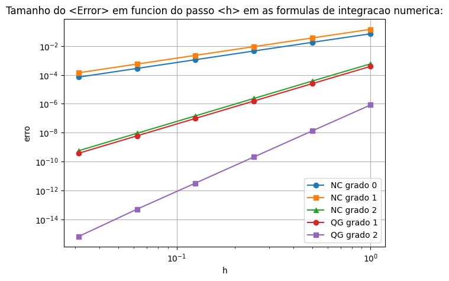

```python
a = 0.
b = 1.
m=[1,2,4,8,16,32]

def f(x):
  return (np.exp(x))

errosNC = np.zeros((3,(len(m))))
hs = np.zeros(len(m))
errosQG = np.zeros((2,(len(m))))

for j in range(len(m)):
  hs[j]=(b-a)/m[j]

for i in range(3):
  for j in range(len(m)):
    errosNC[i,j]=abs(quad(f, a, b)[0]-formula_quadratura_composta(f,a,b,m[j],'NC',i))
    #print("NC com i= ", i," m= ",m[j], " " ,formula_quadratura_composta(f,a,b,m[j],'NC',i))
    if i<=1:
      errosQG[i,j]=abs(quad(f, a, b)[0]-formula_quadratura_composta(f,a,b,m[j],'QG',i+1))
      #print("QG com i= ", i," m= ",m[j], " " ,formula_quadratura_composta(f,a,b,m[j],'QG',i+1))

convergenciaNC = np.zeros((3,(len(m)-1)))
convergenciaQG = np.zeros((2,(len(m)-1)))

for i in range(3):
  convergenciaNC[i,:] = ordem_convergencia_numerica(hs,errosNC[i,:])
  if i <= 1:
    convergenciaQG[i,:] = ordem_convergencia_numerica(hs,errosQG[i,:])
#print("errosNC\n",errosNC)
#print("errosQG\n",errosQG)
#print("convergenciaNC\n",convergenciaNC)
#print("convergenciaQG\n",convergenciaQG)
#print("hs\n",hs)

print("Ordem de convergência estimada numericamente:")
print("NEWTON-COTES:(com m em:",m,")")
for i in range(3):
  print("NC com n=", i,":" , convergenciaNC[i,:])
print("QUADRATURA GAUSSIANA:(com m em:",m,")")
for i in range(2):
  print("QG com n=", i+1, ":" , convergenciaQG[i,:])

plt.figure(figsize=(7,5))
plt.xlabel('h')
plt.ylabel('erro')
plt.yscale('log')
plt.xscale('log')
plt.plot(hs, errosNC[0,:], 'o-', label='NC grado 0')
plt.plot(hs, errosNC[1,:], 's-', label='NC grado 1')
plt.plot(hs, errosNC[2,:], '^-', label='NC grado 2')
plt.plot(hs, errosQG[0,:], 'o-', label='QG grado 1')
plt.plot(hs, errosQG[1,:], 's-', label='QG grado 2')
plt.title('Tamanho do <Error> em funcion do passo <h> em as formulas de integracao numerica:')
plt.grid()
plt.legend()
plt.show()
```

**Os resultados são coerentes com o que se espera teoricamente?**